# Model: Densenet

## Install dependencies

```python
%pip install scikit-learn
%pip install torch
%pip install torchvision
%pip install pandas
%pip install matplotlib
```

```
Python(4235) MallocStackLogging: can't turn off malloc stack logging because it was not enabled.
```

```
Python(4242) MallocStackLogging: can't turn off malloc stack logging because it was not enabled.
```

```
Python(4244) MallocStackLogging: can't turn off malloc stack logging because it was not enabled.
```

## Training

Start by importing the required libraries:

```python
# Example followed from https://www.kaggle.com/code/stpeteishii/sports-ball-15-torch-densenet121/notebook

import os
import random
from sklearn.model_selection import train_test_split
import time
import pickle
import numpy as np
import pandas as pd
import matplotlib.pyplot as plt
%matplotlib inline
import warnings
warnings.filterwarnings("ignore")
import torch
import torch.nn as nn
import torch.nn.functional as F
from torch.utils.data import DataLoader, random_split
from torchvision import datasets, transforms, models
from torchvision.utils import make_grid
from sklearn import metrics
import seaborn as sn
```

Next, a transformation for the data is defined:

```python
transform=transforms.Compose([
        transforms.RandomRotation(10),      # rotate +/- 10 degrees
        transforms.RandomHorizontalFlip(),  # reverse 50% of images
        transforms.Resize(224),             # resize shortest side to 224 pixels
        transforms.CenterCrop(224),         # crop longest side to 224 pixels at center
        transforms.ToTensor(),
        transforms.Normalize([0.485, 0.456, 0.406],
                             [0.229, 0.224, 0.225])
])
```

The training and test images are loaded, using the above defined transformation. Note: change the value of "root" to the (relative) path of the train and test data folder on your machine.

```python
train_ds=datasets.ImageFolder(root="data/train",transform=transform)
test_ds=datasets.ImageFolder(root="data/test",transform=transform)
```

Print the labels associated with the data:

```python
class_names=train_ds.classes
print(class_names)
```

```
['american_football', 'baseball', 'basketball', 'billiard_ball', 'bowling_ball', 'cricket_ball', 'football', 'golf_ball', 'hockey_ball', 'hockey_puck', 'rugby_ball', 'shuttlecock', 'table_tennis_ball', 'tennis_ball', 'volleyball']
```

The train and test set are loaded, together with a batch size:

```python
batch_size = 32
train_loader=DataLoader(train_ds,batch_size=batch_size,shuffle=True)
test_loader=DataLoader(test_ds,batch_size=batch_size)
```

As an example, the labels from the first batch are shown below:

```python
for images, labels in train_loader:
    break
# print the labels for the first batch
print('Label:', labels.numpy())
print('Class:', *np.array([class_names[i] for i in labels]))

im=make_grid(images,nrow=16)
```

```
Label: [11 11  3  3  6  7  5  4  7  3  3 12 10  5  4  4 13  5  4  7 12  8  0  6
  4 10 10  4  3  5 12  5]
Class: shuttlecock shuttlecock billiard_ball billiard_ball football golf_ball cricket_ball bowling_ball golf_ball billiard_ball billiard_ball table_tennis_ball rugby_ball cricket_ball bowling_ball bowling_ball tennis_ball cricket_ball bowling_ball golf_ball table_tennis_ball hockey_ball american_foo…
```

```
Clipping input data to the valid range for imshow with RGB data ([0..1] for floats or [0..255] for integers).
```

[figure not shown]

```python
plt.figure(figsize=(15,15))
plt.imshow(np.transpose(im.numpy(),(1,2,0)))
```

```python
inv_normalize=transforms.Normalize(mean=[-0.485/0.229,-0.456/0.224,-0.406/0.225],
                                    std=[1/0.229,1/0.224,1/0.225])
im=inv_normalize(im)
```

[figure not shown]

```python
plt.figure(figsize=(15,15))
plt.imshow(np.transpose(im.numpy(),(1,2,0)))
```

Set the seed for reproducibility:

```python
torch.manual_seed(42)
```

```
<torch._C.Generator at 0x153cbbd70>
```

The model used is Densenet 121, consisting of several layers:

```python
model= models.densenet121(pretrained=True)

for param in model.parameters():
    param.requires_grad=False

model.classifier=nn.Sequential( nn.Linear(1024,512),
                                nn.ReLU(),
                                nn.Dropout(p=0.5),
                                nn.Linear(512,15),
                                nn.LogSoftmax(dim=1))
```

```
Downloading: "https://download.pytorch.org/models/densenet121-a639ec97.pth" to /Users/stevenvanroye/.cache/torch/hub/checkpoints/densenet121-a639ec97.pth
100.0%
```

```python
model
```

```
DenseNet(
  (features): Sequential(
    (conv0): Conv2d(3, 64, kernel_size=(7, 7), stride=(2, 2), padding=(3, 3), bias=False)
    (norm0): BatchNorm2d(64, eps=1e-05, momentum=0.1, affine=True, track_running_stats=True)
    (relu0): ReLU(inplace=True)
    (pool0): MaxPool2d(kernel_size=3, stride=2, padding=1, dilation=1, ceil_mode=False)
    (denseblock1): _DenseBlock(
      (denselayer1): _DenseLayer(
        (norm1): BatchNorm2d(64, eps=1e-05, momentum=0.1, affine=True, track_running_stats=True)
        (relu1): ReLU(inplace=True)
        (conv1): Conv2d(64, 128, kernel_size=(1, 1), stride=(1, 1), bias=False)
        (norm2): BatchNorm2d(128, eps=1e-05, momentum=0.1, affine=True, track_running_stats=True)
        (relu2): ReLU(inplace=True)
        (conv2): Conv2d(128, 32, kernel_size=(3, 3), stride=(1, 1), padding=(1, 1), bias=False)
      )
      (denselayer2): _DenseLayer(
        (norm1): BatchNorm2d(96, eps=1e-05, momentum=0.1, affine=True, track_running_stats=True)
        (relu1): ReLU(inplace=True)
        (conv1): Conv2d(96, 128, kernel_size=(1, 1), stride=(1, 1), bias=False)
        (norm2): BatchNorm2d(128, eps=1e-05, momentum=0.1, affine=True, track_running_stats=True)
        (relu2): ReLU(inplace=True)
        (conv2): Conv2d(128, 32, kernel_size=(3, 3), stride=(1, 1), padding=(1, 1), bias=False)
      )
      (denselayer3): _DenseLayer(
        (norm1): BatchNorm2d(128, eps=1e-05, momentum=0.1, affine=True, track_running_stats=True)
        (relu1): ReLU(inplace=True)
        (conv1): Conv2d(128, 128, kernel_size=(1, 1), stride=(1, 1), bias=False)
        (norm2): BatchNorm2d(128, eps=1e-05, momentum=0.1, affine=True, track_running_stats=True)
        (relu2): ReLU(inplace=True)
        (conv2): Conv2d(128, 32, kernel_size=(3, 3), stride=(1, 1), padding=(1, 1), bias=False)
      )
      (denselayer4): _DenseLayer(
        (norm1): BatchNorm2d(160, eps=1e-05, momentum=0.1, affine=True, track_running_stats=True)
        (relu1): ReLU(inplace=True)
        (conv1): Conv2d(160, 128, kernel_size=(1, 1), stride=(1, 1), bias=False)
        (norm2): BatchNorm2d(128, eps=1e-05, momentum=0.1, affine=True, track_running_stats=True)
        (relu2): ReLU(inplace=True)
        (conv2): Conv2d(128, 32, kernel_size=(3, 3), stride=(1, 1), padding=(1, 1), bias=False)
      )
      (denselayer5): _DenseLayer(
```

[output cut: 451 more lines]

```
        (norm2): BatchNorm2d(128, eps=1e-05, momentum=0.1, affine=True, track_running_stats=True)
        (relu2): ReLU(inplace=True)
        (conv2): Conv2d(128, 32, kernel_size=(3, 3), stride=(1, 1), padding=(1, 1), bias=False)
      )
    )
    (norm5): BatchNorm2d(1024, eps=1e-05, momentum=0.1, affine=True, track_running_stats=True)
  )
  (classifier): Sequential(
    (0): Linear(in_features=1024, out_features=512, bias=True)
    (1): ReLU()
    (2): Dropout(p=0.5, inplace=False)
    (3): Linear(in_features=512, out_features=15, bias=True)
    (4): LogSoftmax(dim=1)
  )
)
```

```python
def count_parameters(model):
    params = [p.numel() for p in model.parameters() if p.requires_grad]
    for item in params:
        print(f'{item:>8}')
    print(f'________\n{sum(params):>8}')

count_parameters(model)
```

```
  524288
     512
    7680
      15
________
  532495
```

Define the loss function and optimizer used in training phase:

```python
criterion=nn.CrossEntropyLoss()
optimizer=torch.optim.Adam(model.classifier.parameters(),lr=0.001)
```

Set the number of epochs:

```python
epochs=15
```

Actual training of the model (note: something wrong with printing the accuracy):

```python
start_time=time.time()
train_losses=[]
test_losses=[]
train_correct=[]
test_correct=[]

for i in range(epochs):
    trn_corr=0
    tst_corr=0
    for b, (X_train,y_train) in enumerate(train_loader):
        b+=1

        y_pred=model(X_train)
        loss=criterion(y_pred,y_train)
        #Update parameters
        predicted=torch.max(y_pred.data,1)[1]
        batch_corr=(predicted==y_train).sum()
        trn_corr+= batch_corr

        optimizer.zero_grad()
        loss.backward()
        optimizer.step()

        if b%200==0:
            print(f'epoch: {i:2} loss: {loss.item():10.8f}  accuracy: {trn_corr.item():7.3f}%')

    loss=loss.detach().numpy()
    train_losses.append(loss)
    train_correct.append(trn_corr)

    with torch.no_grad():
        for b, (X_test,y_test) in enumerate(test_loader):
            b+=1

            y_val=model(X_test)
            predicted=torch.max(y_val.data,1)[1]
            btach_corr=(predicted==y_test).sum()
            tst_corr+=btach_corr

    loss=criterion(y_val,y_test)
    loss=loss.detach().numpy()
    test_losses.append(loss)
    test_correct.append(tst_corr)

print(f'\nDuration: {time.time() - start_time:.0f} seconds')
```

```
epoch:  0 loss: 0.84521472  accuracy: 3784.000%
epoch:  1 loss: 0.61605299  accuracy: 4834.000%
epoch:  2 loss: 0.78436577  accuracy: 5006.000%
epoch:  3 loss: 0.33463949  accuracy: 5101.000%
epoch:  4 loss: 0.94621634  accuracy: 5190.000%
epoch:  5 loss: 0.54244316  accuracy: 5310.000%
epoch:  6 loss: 0.53259325  accuracy: 5278.000%
epoch:  7 loss: 0.53994286  accuracy: 5354.000%
epoch:  8 loss: 0.48625278  accuracy: 5368.000%
epoch:  9 loss: 0.60926437  accuracy: 5409.000%
epoch: 10 loss: 0.61627913  accuracy: 5456.000%
epoch: 11 loss: 0.95917773  accuracy: 5445.000%
epoch: 12 loss: 0.28923148  accuracy: 5533.000%
epoch: 13 loss: 0.51891518  accuracy: 5500.000%
epoch: 14 loss: 0.55992055  accuracy: 5503.000%

Duration: 57351 seconds
```

```python
device = torch.device("cpu")
```

Check predictions for the test set:

```python
model.eval()
y_true=[]
y_pred=[]
with torch.no_grad():
    for test_data in test_loader:
        test_images, test_labels = test_data[0].to(device), test_data[1].to(device)
        pred = model(test_images).argmax(dim=1)
        for i in range(len(pred)):
            y_true.append(test_labels[i].item())
            y_pred.append(pred[i].item())
print(y_pred[0:5])
```

```
[0, 0, 0, 0, 0]
```

Confusion matrix with sklearn

```
<sklearn.metrics._plot.confusion_matrix.ConfusionMatrixDisplay at 0x193eacc40>
```

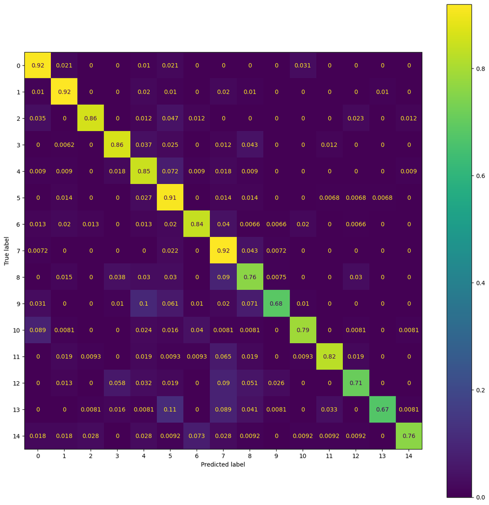

```python
confusion_matrix = metrics.confusion_matrix(y_true, y_pred, normalize='true')
cm_display = metrics.ConfusionMatrixDisplay(confusion_matrix=confusion_matrix)
fig, ax = plt.subplots(figsize=(15,15))
cm_display.plot(ax=ax)
```

Confusion matrix with seaborn

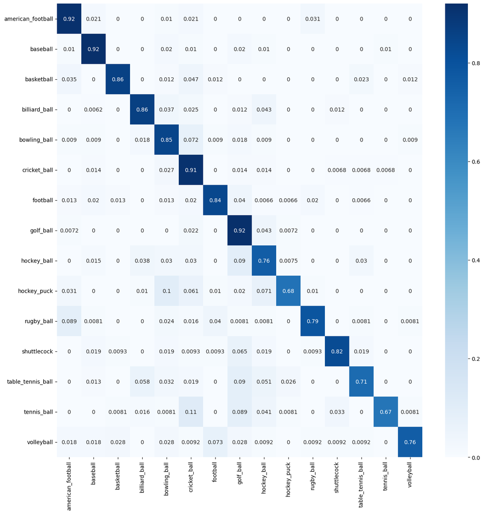

```python
fig, ax = plt.subplots(figsize=(15,15))
sn.heatmap(confusion_matrix, annot=True,cmap="Blues", ax=ax, xticklabels=class_names, yticklabels=class_names)
```

Classification report:

```python
print(metrics.classification_report(y_true, y_pred, target_names=class_names, digits=4))
```

```
                   precision    recall  f1-score   support

american_football     0.7857    0.9167    0.8462        96
         baseball     0.8364    0.9200    0.8762       100
       basketball     0.9136    0.8605    0.8862        86
    billiard_ball     0.8805    0.8642    0.8723       162
     bowling_ball     0.6812    0.8468    0.7550       111
     cricket_ball     0.7037    0.9110    0.7940       146
         football     0.8819    0.8411    0.8610       151
        golf_ball     0.6649    0.9203    0.7720       138
      hockey_ball     0.7063    0.7594    0.7319       133
      hockey_puck     0.8933    0.6837    0.7746        98
       rugby_ball     0.9159    0.7903    0.8485       124
      shuttlecock     0.9175    0.8241    0.8683       108
table_tennis_ball     0.9024    0.7115    0.7957       156
      tennis_ball     0.9765    0.6748    0.7981       123
       volleyball     0.9540    0.7615    0.8469       109

         accuracy                         0.8186      1841
        macro avg     0.8409    0.8191    0.8218      1841
     weighted avg     0.8379    0.8186    0.8199      1841
```

```python
metrics.classification_report(y_true, y_pred, target_names=class_names, digits=4, output_dict=True)
```

```
{'american_football': {'precision': 0.7857142857142857,
  'recall': 0.9166666666666666,
  'f1-score': 0.8461538461538461,
  'support': 96.0},
 'baseball': {'precision': 0.8363636363636363,
  'recall': 0.92,
  'f1-score': 0.8761904761904761,
  'support': 100.0},
 'basketball': {'precision': 0.9135802469135802,
  'recall': 0.8604651162790697,
  'f1-score': 0.8862275449101796,
  'support': 86.0},
 'billiard_ball': {'precision': 0.8805031446540881,
  'recall': 0.8641975308641975,
  'f1-score': 0.8722741433021806,
  'support': 162.0},
 'bowling_ball': {'precision': 0.6811594202898551,
  'recall': 0.8468468468468469,
  'f1-score': 0.7550200803212852,
  'support': 111.0},
 'cricket_ball': {'precision': 0.7037037037037037,
  'recall': 0.910958904109589,
  'f1-score': 0.7940298507462688,
  'support': 146.0},
 'football': {'precision': 0.8819444444444444,
  'recall': 0.8410596026490066,
  'f1-score': 0.8610169491525423,
  'support': 151.0},
 'golf_ball': {'precision': 0.6649214659685864,
  'recall': 0.9202898550724637,
  'f1-score': 0.7720364741641338,
  'support': 138.0},
 'hockey_ball': {'precision': 0.7062937062937062,
  'recall': 0.7593984962406015,
  'f1-score': 0.7318840579710145,
  'support': 133.0},
 'hockey_puck': {'precision': 0.8933333333333333,
  'recall': 0.6836734693877551,
  'f1-score': 0.7745664739884393,
  'support': 98.0},
```

[output cut: 14 more lines]

```
  'f1-score': 0.798076923076923,
  'support': 123.0},
 'volleyball': {'precision': 0.9540229885057471,
  'recall': 0.7614678899082569,
  'f1-score': 0.846938775510204,
  'support': 109.0},
 'accuracy': 0.8185768604019554,
 'macro avg': {'precision': 0.840924240831578,
  'recall': 0.8190504161499755,
  'f1-score': 0.8217928034420235,
  'support': 1841.0},
 'weighted avg': {'precision': 0.8379022476984951,
  'recall': 0.8185768604019554,
  'f1-score': 0.8199395015017473,
  'support': 1841.0}}
```

Accuracy score:

```python
metrics.accuracy_score(y_true, y_pred)
```

```
0.8185768604019554
```

Save the model using pickle:

```python
with open('model.pickle', 'wb') as f:
    pickle.dump(model, f)
```

```python
model
```

```
DenseNet(
  (features): Sequential(
    (conv0): Conv2d(3, 64, kernel_size=(7, 7), stride=(2, 2), padding=(3, 3), bias=False)
    (norm0): BatchNorm2d(64, eps=1e-05, momentum=0.1, affine=True, track_running_stats=True)
    (relu0): ReLU(inplace=True)
    (pool0): MaxPool2d(kernel_size=3, stride=2, padding=1, dilation=1, ceil_mode=False)
    (denseblock1): _DenseBlock(
      (denselayer1): _DenseLayer(
        (norm1): BatchNorm2d(64, eps=1e-05, momentum=0.1, affine=True, track_running_stats=True)
        (relu1): ReLU(inplace=True)
        (conv1): Conv2d(64, 128, kernel_size=(1, 1), stride=(1, 1), bias=False)
        (norm2): BatchNorm2d(128, eps=1e-05, momentum=0.1, affine=True, track_running_stats=True)
        (relu2): ReLU(inplace=True)
        (conv2): Conv2d(128, 32, kernel_size=(3, 3), stride=(1, 1), padding=(1, 1), bias=False)
      )
      (denselayer2): _DenseLayer(
        (norm1): BatchNorm2d(96, eps=1e-05, momentum=0.1, affine=True, track_running_stats=True)
        (relu1): ReLU(inplace=True)
        (conv1): Conv2d(96, 128, kernel_size=(1, 1), stride=(1, 1), bias=False)
        (norm2): BatchNorm2d(128, eps=1e-05, momentum=0.1, affine=True, track_running_stats=True)
        (relu2): ReLU(inplace=True)
        (conv2): Conv2d(128, 32, kernel_size=(3, 3), stride=(1, 1), padding=(1, 1), bias=False)
      )
      (denselayer3): _DenseLayer(
        (norm1): BatchNorm2d(128, eps=1e-05, momentum=0.1, affine=True, track_running_stats=True)
        (relu1): ReLU(inplace=True)
        (conv1): Conv2d(128, 128, kernel_size=(1, 1), stride=(1, 1), bias=False)
        (norm2): BatchNorm2d(128, eps=1e-05, momentum=0.1, affine=True, track_running_stats=True)
        (relu2): ReLU(inplace=True)
        (conv2): Conv2d(128, 32, kernel_size=(3, 3), stride=(1, 1), padding=(1, 1), bias=False)
      )
      (denselayer4): _DenseLayer(
        (norm1): BatchNorm2d(160, eps=1e-05, momentum=0.1, affine=True, track_running_stats=True)
        (relu1): ReLU(inplace=True)
        (conv1): Conv2d(160, 128, kernel_size=(1, 1), stride=(1, 1), bias=False)
        (norm2): BatchNorm2d(128, eps=1e-05, momentum=0.1, affine=True, track_running_stats=True)
        (relu2): ReLU(inplace=True)
        (conv2): Conv2d(128, 32, kernel_size=(3, 3), stride=(1, 1), padding=(1, 1), bias=False)
      )
      (denselayer5): _DenseLayer(
```

[output cut: 451 more lines]

```
        (norm2): BatchNorm2d(128, eps=1e-05, momentum=0.1, affine=True, track_running_stats=True)
        (relu2): ReLU(inplace=True)
        (conv2): Conv2d(128, 32, kernel_size=(3, 3), stride=(1, 1), padding=(1, 1), bias=False)
      )
    )
    (norm5): BatchNorm2d(1024, eps=1e-05, momentum=0.1, affine=True, track_running_stats=True)
  )
  (classifier): Sequential(
    (0): Linear(in_features=1024, out_features=512, bias=True)
    (1): ReLU()
    (2): Dropout(p=0.5, inplace=False)
    (3): Linear(in_features=512, out_features=15, bias=True)
    (4): LogSoftmax(dim=1)
  )
)
```

Predict a new image

```python
from PIL import Image, ImageFile
ImageFile.LOAD_TRUNCATED_IMAGES = True
from ipyfilechooser import FileChooser

# Select image and predict based on the model: see https://medium.com/@nutanbhogendrasharma/image-classification-with-pytorch-351a0a6cc09d

def show_filepicker():
    fc = FileChooser()
    display(fc)
    return fc

def get_image(file_name):
    img = Image.open(file_name)
    img = transform(img).to(device)
    img = torch.unsqueeze(img, 0)
    return img
```

```python
def get_prediction(model, img):
    model.eval()
    prediction = F.softmax(model(img), dim=1)
    prediction = prediction.argmax()
    return class_names[prediction]
```

```python
fc = show_filepicker()
```

```
FileChooser(path='/Users/stevenvanroye/PycharmProjects/Cloud-For-AI-Assignment/trial', filename='', title='', …
```

```python
img = get_image(fc.selected)
```

For testing purposes: read the model from the pickle file:

```python
def get_model():
    with open('model.pickle', 'rb') as f:
        new_model = pickle.load(f)
    return new_model
```

```python
new_model = get_model()
```

```python
get_prediction(new_model, img)
```

```
'baseball'
```

ROC curve

```python
import torch
from sklearn.metrics import roc_curve, auc
from sklearn.preprocessing import label_binarize
import matplotlib.pyplot as plt
from itertools import cycle


def get_test_labels_and_probs(model):
    model.eval()
    all_labels = []
    all_probs = []

    with torch.no_grad():
        for inputs, labels in test_loader:
            outputs = model(inputs)
            probabilities = torch.nn.functional.softmax(outputs, dim=1)
            all_labels.extend(labels.cpu().numpy())
            all_probs.extend(probabilities.cpu().numpy())
    return all_labels, all_probs


def plot_roc(labels, probs):
    # Binarize the labels
    num_classes = len(set(labels))
    binarized_labels = label_binarize(labels, classes=list(range(num_classes)))

    # Calculate ROC curve metrics for each class
    fpr = dict()
    tpr = dict()
    roc_auc = dict()

    for i in range(num_classes):
        fpr[i], tpr[i], _ = roc_curve(binarized_labels[:, i], probs[:, i])
        roc_auc[i] = auc(fpr[i], tpr[i])

    plt.figure(figsize=(10, 6))
    colors = cycle(['aqua', 'darkorange', 'cornflowerblue'])
    for i, color in zip(range(num_classes), colors):
        plt.plot(fpr[i], tpr[i], color=color, lw=2, label='ROC curve (class {})'.format(i))

    plt.plot([0, 1], [0, 1], color='navy', lw=2, linestyle='--')
    plt.xlabel('False Positive Rate')
    plt.ylabel('True Positive Rate')
    plt.title('Receiver Operating Characteristic (ROC) Curve for Multi-Class')
    plt.legend(loc='lower right')
    plt.show()
```

```python
labels, probs = get_test_labels_and_probs(new_model)
```

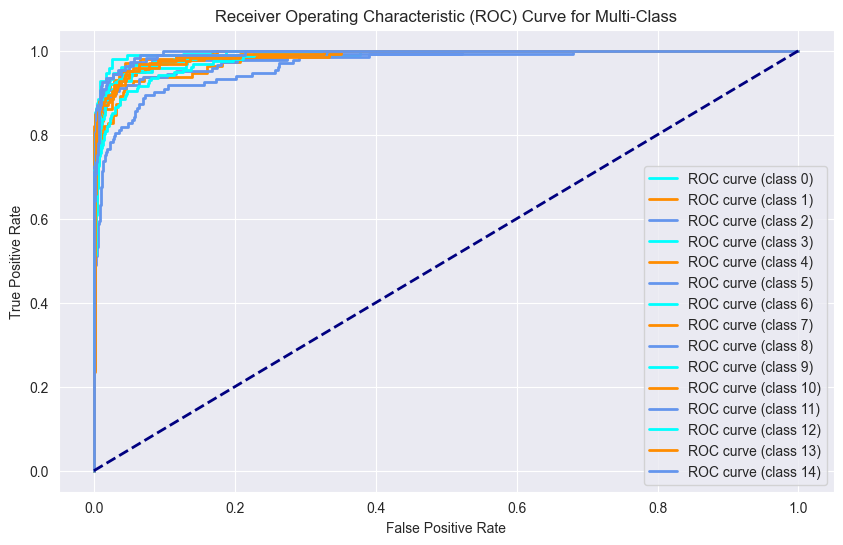

```python
plot_roc(labels, np.array(probs))
```